[figure not shown]

# Technical Support Data Analysis

Technical support data can often be a rich source of information on opportunities for improving customer experience. The lesser the trouble customers have with the product the better. Even better when the customers are able to overcome technical challenge quickly with minimal effort. Let us analyze the tech support data and do some basic analysis on problem types, time to resolve the problem and channel of suppor that is most suitable

## Loading the Dataset

```python
import pandas as pd
import numpy as np

import matplotlib.pylab as plt
%matplotlib inline

import seaborn as sns
#from sklearn.model_selection  import train_test_split
from sklearn.cluster import KMeans

from scipy.stats import zscore
```

```python
tech_supp_df = pd.read_csv("technical_support_data-2.csv")
```

The dataset contains one record for each unique problem type. It has metrics for each type like count, average calls to resolve, average resolution time etc.

```python
tech_supp_df.shape #printing the shape of the dataset
```

```
(23, 8)
```

```python
tech_supp_df.head() #the first 5 rows
```

|  | PROBLEM_TYPE | no_of_cases | Avg_pending_calls | Avg_resol_time | recurrence_freq | Replace_percent | In_warranty_percent | Post_warranty_percent |
| --- | --- | --- | --- | --- | --- | --- | --- | --- |
| 0 | Temperature control not working | 170 | 1.3 | 32 | 0.04 | 0.0 | 75 | 25 |
| 1 | power chord does not tightly fit | 12 | 2.0 | 150 | 0.01 | 0.5 | 5 | 95 |
| 2 | Fan swing not working | 5 | 1.0 | 35 | 0.02 | 0.2 | 90 | 10 |
| 3 | Main switch does not on | 3 | 2.0 | 8 | 0.01 | 0.7 | 5 | 95 |
| 4 | Forgot mobile app password | 45 | 2.3 | 54 | 0.15 | 0.0 | 99 | 1 |

```python
techSuppAttr=tech_supp_df.iloc[:,1:]  #leaving out the problem type since there's no need performing our model on that
techSuppScaled=techSuppAttr.apply(zscore) #scalling out data
```

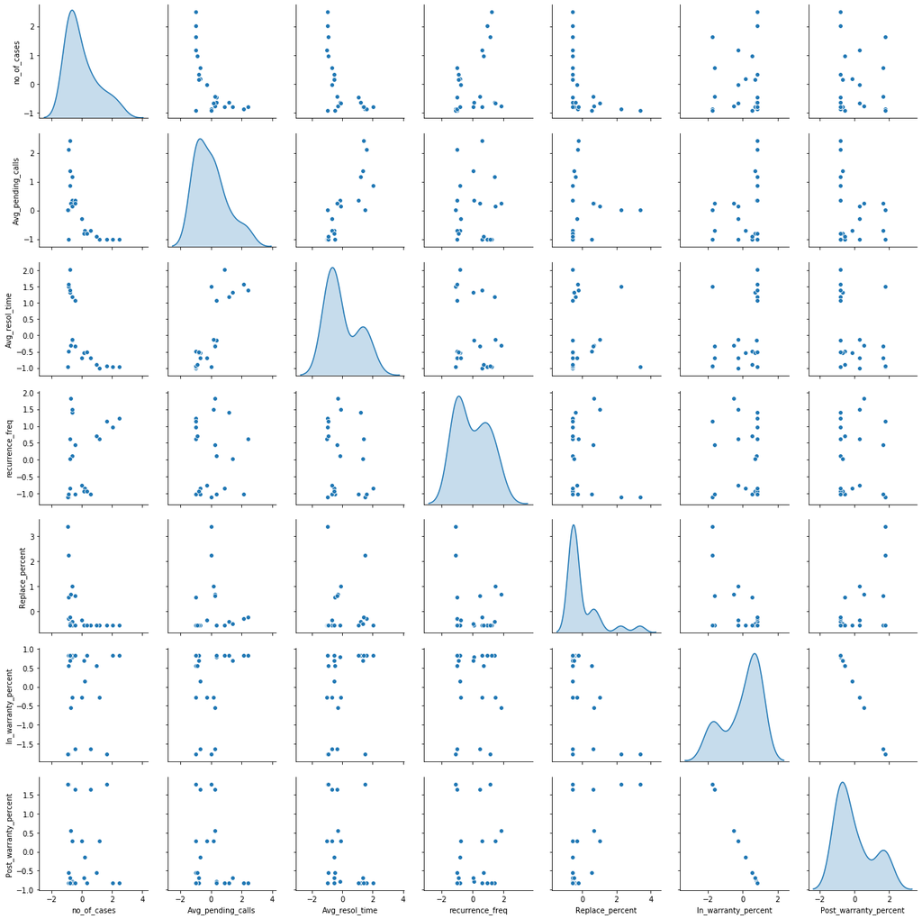

```python
sns.pairplot(techSuppScaled,diag_kind='kde') #a pairplot of the various attributes
```

## Group Data into similar clusters

Now, we will use K-Means clustering to group data based on their attribute. First, we need to determine the optimal number of groups. We are going to use the elbow method

Read: pdist, cdist : 1) https://docs.scipy.org/doc/scipy/reference/generated/scipy.spatial.distance.cdist.html 2) http://library.isr.ist.utl.pt/docs/scipy/spatial.distance.html

### The elbow Method

```python
#Finding optimal no. of clusters
from scipy.spatial.distance import cdist #Compute distance between each pair of the two collections of inputs.
clusters=range(1,10)
meanDistortions=[]

for k in clusters:
    model=KMeans(n_clusters=k)
    model.fit(techSuppScaled)
    prediction=model.predict(techSuppScaled)
    meanDistortions.append(sum(np.min(cdist(techSuppScaled, model.cluster_centers_, 'euclidean'), axis=1)) / techSuppScaled.shape[0])
```

```python
meanDistortions
```

```
[2.5132186215720433,
 2.011069807948648,
 1.6368266300358516,
 1.4661262666709103,
 1.2388389765644354,
 1.0683763656941434,
 0.9815040637871221,
 0.8471342451478266,
 0.7700442618100034]
```

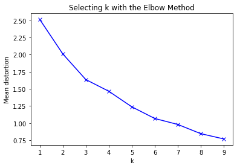

```python
plt.plot(clusters, meanDistortions, 'bx-')
plt.xlabel('k')
plt.ylabel('Mean distortion')
plt.title('Selecting k with the Elbow Method')
```

Though the bend is not coming out clearly as there are many bends, let us look at 3 clusters and 5 clusters

```python
# Let us first start with K = 3
final_model=KMeans(3)
final_model.fit(techSuppScaled)
prediction=final_model.predict(techSuppScaled)
```

```python
#Append the prediction
tech_supp_df["Clusters"] = prediction
tech_supp_df.head()
```

|  | PROBLEM_TYPE | no_of_cases | Avg_pending_calls | Avg_resol_time | recurrence_freq | Replace_percent | In_warranty_percent | Post_warranty_percent | Clusters |
| --- | --- | --- | --- | --- | --- | --- | --- | --- | --- |
| 0 | Temperature control not working | 170 | 1.3 | 32 | 0.04 | 0.0 | 75 | 25 | 2 |
| 1 | power chord does not tightly fit | 12 | 2.0 | 150 | 0.01 | 0.5 | 5 | 95 | 0 |
| 2 | Fan swing not working | 5 | 1.0 | 35 | 0.02 | 0.2 | 90 | 10 | 2 |
| 3 | Main switch does not on | 3 | 2.0 | 8 | 0.01 | 0.7 | 5 | 95 | 0 |
| 4 | Forgot mobile app password | 45 | 2.3 | 54 | 0.15 | 0.0 | 99 | 1 | 1 |

```python
tech_supp_df[tech_supp_df['Clusters']==2] #now I can see which problems have been grouped together (keep changing it from 0-2 to see various problem type)
```

[output not shown]

```python
#  Let us next try with K = 5, the next elbow point
```

```python
# Let us start with K = 5
final_model=KMeans(5)
final_model.fit(techSuppScaled)
prediction=final_model.predict(techSuppScaled)
```

```python
#Append the prediction
tech_supp_df["Clusters"] = prediction

print("Clusters Assigned : \n")
tech_supp_df.head()
```

```
Clusters Assigned :
```

|  | PROBLEM_TYPE | no_of_cases | Avg_pending_calls | Avg_resol_time | recurrence_freq | Replace_percent | In_warranty_percent | Post_warranty_percent | Clusters |
| --- | --- | --- | --- | --- | --- | --- | --- | --- | --- |
| 0 | Temperature control not working | 170 | 1.3 | 32 | 0.04 | 0.0 | 75 | 25 | 0 |
| 1 | power chord does not tightly fit | 12 | 2.0 | 150 | 0.01 | 0.5 | 5 | 95 | 4 |
| 2 | Fan swing not working | 5 | 1.0 | 35 | 0.02 | 0.2 | 90 | 10 | 0 |
| 3 | Main switch does not on | 3 | 2.0 | 8 | 0.01 | 0.7 | 5 | 95 | 4 |
| 4 | Forgot mobile app password | 45 | 2.3 | 54 | 0.15 | 0.0 | 99 | 1 | 0 |

```python
tech_supp_df[tech_supp_df['Clusters']==4]['PROBLEM_TYPE'] #now I can see which problems have been grouped together (keep changing it from 0-2 to see various problem type)
```

```
1    power chord does not tightly fit
3             Main switch does not on
Name: PROBLEM_TYPE, dtype: object
```